# Python Basics: a tutorial for the NOAA Satellite Workshop

> notebook filename | python_basics.ipynb  
> history | created Sept. 14, 2019  
> owner | NOAA CoastWatch West Coast Node

In this exercise, you will use Python to download data and metadata from ERDDAP.

The exercise demonstrates the following skills:

- Using Python to retrieve information about a dataset from ERDDAP
- Getting data from a remote CSV file
- Downloading satellite data from ERDDAP in netCDF format
- Extracting data with Python

For the examples in this exercise we will use the SMAP Sea Surface Salinity dataset from the CoastWatch West Coast Node (ERDDAP ID = jplSMAPSSSv42_mday).  
https://coastwatch.pfeg.noaa.gov/erddap/griddap/jplSMAPSSSv42_mday.graph

The dataset has low spatial resolution (0.25 degrees), which will help prevent overloading the local intenet bandwidth during the class.

The scripts in this exercise are written in Python 3.7.

## Get set up

### Import python modules

```python
import netCDF4
import urllib.request
import requests
import io
import os
import copy
import numpy as np
import numpy.ma as ma
from datetime import datetime
import time
import matplotlib.pyplot as plt
import matplotlib
from matplotlib.patches import Polygon
from pandas.plotting import register_matplotlib_converters
register_matplotlib_converters()
os.environ['PROJ_LIB'] = '/Users/DaleRobinson/anaconda/envs/python37/share/basemap'
from mpl_toolkits.basemap import Basemap
from dateutil.parser import parse
import pandas as pd
import sys
```

### Change active directory to the location of the notebook file

```python
# Load directory path in the IPYNB_DIR variable
IPYNB_DIR = './'

# Change directory
os.chdir(IPYNB_DIR)
```

## Getting information about a dataset

### An ERDDAP has an interface for gathering information about any or all datasets

- Go to the ERDDAP Active Datasets page  
  https://coastwatch.pfeg.noaa.gov/erddap/tabledap/allDatasets.html  
  The page shows you all of the metadata that you can collect for any or all datasets.
- Use the `Uncheck all` button to deselect all of the metadata variable
- Check the `datasetID` row. In the `Optional Constraint #1` column change the dropdown to `=` and paste in the dataset ID with double quoates around it: "jplSMAPSSSv42_mday"
- Check the following rows: 'minLongitude', 'maxLongitude', 'minLatitude', 'maxLatitude', 'minTime', and 'maxTime'
- Now click the `Submit` button

ERDDAP loads a page showing information about the dataset. The information is in HTML format. We want to get it in CSV format to load it into Python.

- Use the browser back button to return to the ERDDAP Active Datasets page.
- Use the `file type` dropdown (just above the `Submit` button) to select a `csv` file type.
- Then click the `Just generate the url` button and copy the URL.

**In the script below the URL we generated in ERDDAP is pasted into the myurl variable. The script uses this URL to bring the metadata into a Pandas dataframe.**

```python
# paste the URL you copied into the myurl variable
myurl = 'https://coastwatch.pfeg.noaa.gov/erddap/tabledap/allDatasets.csv?datasetID,minLongitude,maxLongitude,minLatitude,maxLatitude,minTime,maxTime&datasetID="jplSMAPSSSv42_mday"'

# Point to the metadata using 'requests'
pointer = requests.get(myurl).content

# Load the metadata into a Pandas dataframe
myDF = pd.read_csv(io.StringIO(pointer.decode('utf-8')))
myDF
```

|  | datasetID | minLongitude | maxLongitude | minLatitude | maxLatitude | minTime | maxTime |
| --- | --- | --- | --- | --- | --- | --- | --- |
| 0 | NaN | degrees_east | degrees_east | degrees_north | degrees_north | UTC | UTC |
| 1 | jplSMAPSSSv42_mday | -179.875 | 179.875 | -89.875 | 89.875 | 2015-04-16T00:00:00Z | 2019-08-16T00:00:00Z |

## Download data from ERDDAP

### Getting the data request URL from ERDDAP

Follow this URL to an ERDDAP view of the "jplSMAPSSSv42_mday" dataset that is zoomed in on the Gulf of Mexico:  
https://coastwatch.pfeg.noaa.gov/erddap/griddap/jplSMAPSSSv42_mday.graph?smap_sss[(2019-07-16T00:00:00Z)][(35.875):(15.875)][(-100.875):(-80.875)]

- Click on the 'Data Access Form' link at the top of the page
- In the `time (UTC)` row, change the `Start` time to `2019-04-16T00:00:00Z`
- Use the `file type` dropdown (just above the `Submit` button) to select a `.nc` (netCDF) file type.
- Then click the `Just generate the url` button and copy the URL.

The URL has been assigned to the `myURL` variable below. We will use it to download the SSS data as a netCDF file using the Python script below.

```python
# Past URL here
myURL = 'https://coastwatch.pfeg.noaa.gov/erddap/griddap/jplSMAPSSSv42_mday.nc?smap_sss[(2019-04-16T00:00:00Z):1:(2019-07-16T00:00:00Z)][(35.875):(15.875)][(-100.875):(-80.875)]'

# This downloads the nc file and names in myNC.nc
urllib.request.urlretrieve(myURL, 'myNC.nc')
```

```
('myNC.nc', <http.client.HTTPMessage at 0x118a529e8>)
```

### Use the netCDF4 module to open the downloaded file

- The "r" indicates that we are opening the file in read-only mode.

```python
nc = netCDF4.Dataset('myNC.nc', "r")
```

### View the variables in the downloaded file

Variable names are held as dictionary keys. You can view all of the variables using this method: `nc.variables.keys()`. Below `nc.variables.keys()` is formatted in a print statement to make it more readable.

**There are three coordinate variables (time, latitude, longitude) and the data variable (smap_sss).**

```python
# Display the variables nicely
print('dataset variables = ', ', '.join( nc.variables.keys()) )
```

```
dataset variables =  time, latitude, longitude, smap_sss
```

### List information about the SSS variable

**You can list information about the variable by creating a pointer to it and printing the pointer variable.**

- Beside the variable name are listed the dimensions associated with the smap_sss data [`smap_sss(time, latitude, longitude)`].
- The `current shape` (4, 81, 81) list the size of each dimension (i.e time=4, latitude=81, longitude=81)

```python
# Create a pointer to the smap_sss data variable
sss_obj = nc.variables['smap_sss']
print(sss_obj)
```

```
<class 'netCDF4._netCDF4.Variable'>
float32 smap_sss(time, latitude, longitude)
    _FillValue: -9999.0
    colorBarMaximum: 37.0
    colorBarMinimum: 32.0
    coverage_content_type: physicalMeasurement
    ioos_category: Salinity
    long_name: SMAP sea surface salinity
    standard_name: sea_water_practical_salinity
    units: PSU
    valid_max: 45.0
    valid_min: 0.0
unlimited dimensions:
current shape = (4, 81, 81)
filling on
```

**You can get the information about any of the other variables, for example the time coordinate variable.**

- Note that the time variable is one dimensional, as are all of the coordinate variables, and has the same name of the time dimension.
- Later we will need to know the units of time (`seconds since 1970-01-01T00:00:00Z`, see below) to work with time in Python

```python
# Create a pointer to the time coordinate variable
time_obj = nc.variables['time']
print(time_obj)
```

```
<class 'netCDF4._netCDF4.Variable'>
float64 time(time)
    _CoordinateAxisType: Time
    actual_range: [1.5553728e+09 1.5632352e+09]
    axis: T
    ioos_category: Time
    long_name: Reference time of sss field
    standard_name: time
    time_origin: 01-JAN-1970 00:00:00
    units: seconds since 1970-01-01T00:00:00Z
unlimited dimensions:
current shape = (4,)
filling on, default _FillValue of 9.969209968386869e+36 used
```

### Pull out the information of interest with dot notation

Now that you have pointers to a variable you can get to the information about it using dot notation.

- e.g. print(sss_obj.units) will print the units of 'PSU'

```python
# Look at the variable's name with "sss_obj.long_name"
print('Name = ', sss_obj.long_name)

# Look at the variable's standard name with "sss_obj.long_name"
print('Standard name = ', sss_obj.standard_name)

# Look at the variable dimensions with "sss_obj.dimensions"
print('Dimensions = ', ', '.join(sss_obj.dimensions) )

# Look at the variable dimension's values with "sss_obj.shape"
print('Array shape = ', sss_obj.shape )

# Look at the variable units with "sss_obj.units"
print('Units = ', sss_obj.units)
```

```
Name =  SMAP sea surface salinity
Standard name =  sea_water_practical_salinity
Dimensions =  time, latitude, longitude
Array shape =  (4, 81, 81)
Units =  PSU
```

### Load data for all variables into Python arrays

To use the data form the netCDF file, we need to load it into variables.

```python
sss_data = nc.variables['smap_sss'][:,:,:]
lat_data = nc.variables['latitude'][:]
lon_data = nc.variables['longitude'][:]
time_data = nc.variables['time'][:]

# Close the netCDF file
nc.close()
```

### You are done! You have successfully loaded ERDDAP satellite data into Python.

## Mapping the data

### Verify the times that were downloaded

The dates are in the units "seconds since 1970-01-01T00:00:00Z" so first convert to a Python date object. Then print the dates out in a human readable form.

```python
# convert sec since 1/1/1970 to date objects
time_objs = [datetime.fromtimestamp(ln) for ln in time_data]

# Create date strings in a readable format and print
time_print = [ln.strftime("%b-%Y") for ln in time_objs]
print(', '.join(time_print))
```

```
Apr-2019, May-2019, Jun-2019, Jul-2019
```

### Create maps of the data

#### First create a function to make a quick and dirty plot

```python
def easy_plot(v_lats, v_lons, variable):
    # meshgrid creates 2D grids out of the 1D Lat and Lon vectors
    p_lons, p_lats = np.meshgrid(v_lons, v_lats)

    # Define the plot using matplotlib
    plt.figure()
    plt.scatter(p_lons, p_lats, c=variable, cmap='jet')
    cbar = plt.colorbar()
    cbar.set_label('Salinity (PSU)')
    plt.xlabel('longitude')
    plt.ylabel('latitude')

    #Plot the map
    plt.show()
```

### Use a 'for loop' to display the four time steps

```
Apr-2019
```

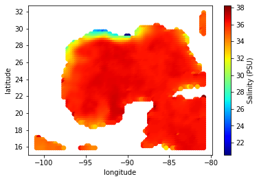

```
May-2019
```

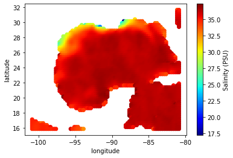

```
Jun-2019
```

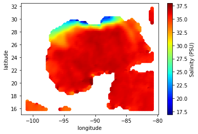

```
Jul-2019
```

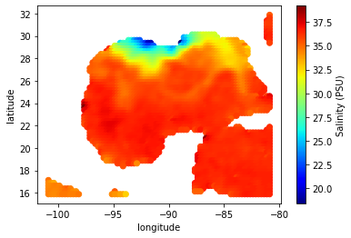

```python
for i in range(0, len(sss_data)):
    print (time_print[i])
    easy_plot( lat_data, lon_data, sss_data[i,:,:])
    time.sleep(.5)
```

## Generate means for each day like the rerddap Xtracto3D function

```python
# Calculate the mean for each latitude and longitude layer (axis 1 and 2)
m_mean = np.nanmean(sss_data, axis=(1,2))
m_mean_print = list(np.around(m_mean, decimals=3, out=None))
m_mean_print = [str(ln) for ln in m_mean_print]

# Calculate the standard deviation for each latitude and longitude layer (axis 1 and 2)
m_std = np.nanstd(sss_data, axis=(1,2))
m_std_print = np.around(m_std, decimals=3, out=None)
m_std_print = [str(ln) for ln in m_std_print]

# Determin the n used for mean and st dev
m_cnt = np.count_nonzero(sss_data, axis=(1,2))
m_cnt_print = [str(ln) for ln in list(m_cnt)]

print( 'means: ',  ', '.join(m_mean_print) )
print( 'stdev: ',  ', '.join(m_mean_print) )
print( 'count: ', ', '.join(m_cnt_print) )
```

```
means:  35.85, 35.768, 35.197, 35.285
stdev:  35.85, 35.768, 35.197, 35.285
count:  2878, 2864, 2822, 2813
```

### Make a simple plot of the means verse time

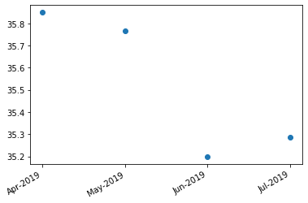

```python
plt.plot_date(time_print, m_mean)
plt.gcf().autofmt_xdate()
plt.show()
```

## Generate means for a polygon like the R rerddapXtractogon function

### Load a csv file that defines the polygon latitude and longitude coordinates

The example uses a polygon for the shelf break on the Gulf of Mexico

```python
# Load CSV into Pandas
myPolygon = pd.read_csv('shelf_boundary_gom.csv')

# list the first 10 values as an example
myPolygon[0:10]
```

|  | lon_gom | lat_gom |
| --- | --- | --- |
| 0 | -96.966386 | 31.000000 |
| 1 | -96.966386 | 25.971454 |
| 2 | -96.914482 | 25.977980 |
| 3 | -96.880843 | 25.987670 |
| 4 | -96.844307 | 25.998187 |
| 5 | -96.821817 | 26.004655 |
| 6 | -96.809842 | 26.008098 |
| 7 | -96.741536 | 26.008842 |
| 8 | -96.693305 | 26.008992 |
| 9 | -96.645073 | 26.009127 |

### Create the polygon path

```python
# Reform the csv data into lon, lat pairs
poly = list(zip(list(myPolygon['lon_gom']), list(myPolygon['lat_gom'])))

# Create a polygon path
poly_p = matplotlib.path.Path(poly)
```

### Create a mask from the polygon path

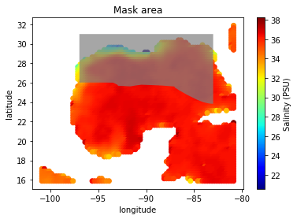

```python
# Flatten and make a list of lomn/lat pairs. Transpose
# Make 2D grids of the lat and lon vectors
p_lons, p_lats = np.meshgrid(lon_data, lat_data)

# Flatten or linearize the grids
latlogList = np.array((p_lons.flatten(), p_lats.flatten())).T

# Create the mask and reshape to 2D (not in the polygon = False)
mask = poly_p.contains_points(latlogList).reshape(p_lons.shape)

#Plot the mask
p_lons, p_lats = np.meshgrid(lon_data, lat_data)
plt.figure()

poly_plot = Polygon( poly, facecolor='gray', alpha=0.7 )
plt.gca().add_patch(poly_plot)

plt.scatter(p_lons, p_lats, c=sss_data[0,:,:], cmap='jet')
cbar = plt.colorbar()
cbar.set_label('Salinity (PSU)')
plt.xlabel('longitude')
plt.ylabel('latitude')
plt.title('Mask area')
plt.show()
```

### Mask the data

```python
# Generate a 3D mask (using broadcast is better)
m1 = copy.deepcopy(mask)
m1 = np.expand_dims(m1, axis = 0)
mask_3d = copy.deepcopy(m1)
for i in range(0, sss_data.shape[0] - 1):
    mask_3d = np.vstack((mask_3d, m1))

# Mask the data
datamasked = ma.masked_where(mask_3d != True, sss_data[:,:,:])
```

### Plot the data in the polygon

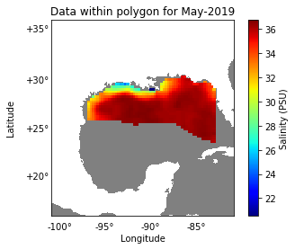

```python
# Use basemap and a projection this time
plt.figure()

# Define the map
m = Basemap(projection = 'mill', llcrnrlon = lon_data.min(), urcrnrlon = lon_data.max(),
          llcrnrlat=lat_data.min(), urcrnrlat=lat_data.max(), resolution="i")

m.drawlsmask(land_color = 'white',ocean_color = 'gray',lakes = True)

xx,yy = m(p_lons, p_lats)

cs = m.pcolormesh(xx, yy, datamasked[0], cmap = 'jet')

m.drawmeridians(np.linspace(-100, -80, num = 5, endpoint = True),
                labels = [0,0,0,1],
                linewidth = 0,
                labelstyle ='+/-',
                yoffset = 80000)

m.drawparallels(np.linspace(15, 35, num = 5, endpoint = True),
                labels = [1,0,0,0],
                linewidth = 0,
                labelstyle = '+/-',
                xoffset = 20000)
plt.xlabel('Longitude', labelpad = 20)
plt.ylabel('Latitude', labelpad = 40)

cbar = plt.colorbar()
cbar.set_label('Salinity (PSU)')
plt.title("Data within polygon for " + time_print[1])
plt.show()
```

### Generate means for the masked data

```python
# Calculate the mean for each latitude and longitude layer (axis 1 and 2)
m2_mean = np.nanmean(datamasked, axis=(1,2))
m2_mean_print = list(np.around(m2_mean, decimals=3, out=None))
m2_mean_print = [str(ln) for ln in m_mean_print]

m2_std = np.nanstd(sss_data, axis = (1,2))
m2_std_print = np.around(m2_std, decimals=3, out=None)
m2_std_print = [str(ln) for ln in m2_std_print]

m2_cnt = np.count_nonzero(sss_data, axis=(1,2))
m2_cnt_print = [str(ln) for ln in list(m2_cnt)]

print( 'means: ',  ', '.join(m2_mean_print) )
print( 'stdev: ',  ', '.join(m2_mean_print) )
print( 'count: ', ', '.join(m2_cnt_print) )
```

```
means:  35.85, 35.768, 35.197, 35.285
stdev:  35.85, 35.768, 35.197, 35.285
count:  2878, 2864, 2822, 2813
```

### Make a simple plot of the means verse time

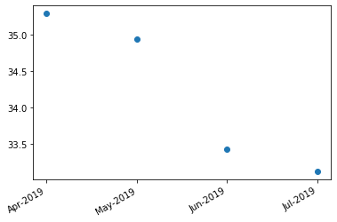

```python
plt.plot_date(time_print, m2_mean)
plt.gcf().autofmt_xdate()
plt.show()
```

### Load a file with the time, latitude, longitude station locations

```python
# Load the file into a Pandas data frame
tk_DF = pd.read_csv('my_track.csv')

# Display the data
display(tk_DF)
```

|  | sample_time | sample_lat | sample_lon |
| --- | --- | --- | --- |
| 0 | 2019-07-16T00:00:00Z | 25.5 | -95.0 |
| 1 | 2019-06-16T00:00:00Z | 27.0 | -86.0 |
| 2 | 2019-05-16T00:00:00Z | 24.0 | -93.2 |
| 3 | 2019-04-16T00:00:00Z | 28.0 | -93.1 |
| 4 | 2019-03-16T00:00:00Z | 23.0 | -95.2 |
| 5 | 2019-03-16T00:00:00Z | 24.0 | -85.0 |

### Create a function that downloads data and generates means

The function incorporates the URL generation, ERDDAP data requests and mean calculations we used above.

```python
def get_open_data(start_date, end_date, lat_min, lat_max, lon_min, lon_max):
    # create the URL
    base_url = 'https://coastwatch.pfeg.noaa.gov/erddap/griddap/'
    id_url = 'jplSMAPSSSv42_mday'
    url_filetype = '.nc?'
    var_url = 'smap_sss'
    time_url = '[(' + start_date + '):1:(' + end_date + ')]'
    lat_url = '[(' + lat_max + '):(' + lat_min + ')]'
    lon_url = '[(' + lon_min + '):(' + lon_max + ')]'

    the_url = ''.join( [base_url, id_url, url_filetype, var_url, time_url, lat_url, lon_url] )
    print(the_url)

    # Download the data
    try:
        print('loading')
        urllib.request.urlretrieve(the_url, 'myNC2.nc')
        print('data')
        nc2 = netCDF4.Dataset('myNC2.nc', "r")
    except:
        print('No ERDDAP responce')

    # bring data into python
    sss_dt = nc2.variables[var_url][:,:,:]
    lat_dt = nc2.variables['latitude'][:]
    lon_dt = nc2.variables['longitude'][:]
    #time_dt = nc2.variables['time'][:]

    nc2.close()

    # Generate means
    m_mean = np.nanmean(sss_dt, axis=(1,2))
    m_mean_print = list(np.around(m_mean, decimals=3, out=None))

    m_std = np.nanstd(sss_dt, axis=(1,2))
    m_std_print = np.around(m_std, decimals=3, out=None)
    m_std_print = [str(ln) for ln in m_std_print]

    m_cnt = np.count_nonzero(sss_dt, axis=(1,2))
    m_cnt_print = [str(ln) for ln in list(m_cnt)]

    return lat_dt.min(), lat_dt.max(), lon_dt.min(), lon_dt.max(), m_mean, m_std, m_cnt
```

### Feed the location data to the function and collect the output

```python
# Pull the location data from the Pandas dataframe
tk_time = list(tk_DF['sample_time'])
tk_lat = list(tk_DF['sample_lat'])
tk_lon = list(tk_DF['sample_lon'])

# Set the size of the box surrounding the lat/lon center points
location_box = .25

# Interate over the location data coordinates
columns = ['sample_date', 'lat_min', 'lat_max', 'lon_min', 'lon_max', 'mean', 'stdev', 'n']
track_data = []

for i in range(0, len(tk_time)):
        start_date1 = tk_time[i]
        end_date1 = tk_time[i]
        lat1_min = str( float(tk_lat[i]) - location_box )
        lat1_max = str( float(tk_lat[i]) + location_box )
        lon1_min = str( float(tk_lon[i]) - location_box )
        lon1_max = str( float(tk_lon[i]) + location_box )

        r = get_open_data(start_date1, end_date1, lat1_min, lat1_max, lon1_min, lon1_max)

        track_data_temp = [start_date1, r[0], r[1], r[2], r[3], r[4][0], r[5][0], r[6][0]]

        track_data.append(track_data_temp)

track_results = pd.DataFrame(track_data, columns=columns)
track_results
```

```
https://coastwatch.pfeg.noaa.gov/erddap/griddap/jplSMAPSSSv42_mday.nc?smap_sss[(2019-07-16T00:00:00Z):1:(2019-07-16T00:00:00Z)][(25.75):(25.25)][(-95.25):(-94.75)]
loading
data
https://coastwatch.pfeg.noaa.gov/erddap/griddap/jplSMAPSSSv42_mday.nc?smap_sss[(2019-06-16T00:00:00Z):1:(2019-06-16T00:00:00Z)][(27.25):(26.75)][(-86.25):(-85.75)]
loading
data
https://coastwatch.pfeg.noaa.gov/erddap/griddap/jplSMAPSSSv42_mday.nc?smap_sss[(2019-05-16T00:00:00Z):1:(2019-05-16T00:00:00Z)][(24.25):(23.75)][(-93.45):(-92.95)]
loading
data
https://coastwatch.pfeg.noaa.gov/erddap/griddap/jplSMAPSSSv42_mday.nc?smap_sss[(2019-04-16T00:00:00Z):1:(2019-04-16T00:00:00Z)][(28.25):(27.75)][(-93.35):(-92.85)]
loading
data
https://coastwatch.pfeg.noaa.gov/erddap/griddap/jplSMAPSSSv42_mday.nc?smap_sss[(2019-03-16T00:00:00Z):1:(2019-03-16T00:00:00Z)][(23.25):(22.75)][(-95.45):(-94.95)]
loading
data
https://coastwatch.pfeg.noaa.gov/erddap/griddap/jplSMAPSSSv42_mday.nc?smap_sss[(2019-03-16T00:00:00Z):1:(2019-03-16T00:00:00Z)][(24.25):(23.75)][(-85.25):(-84.75)]
loading
data
```

|  | sample_date | lat_min | lat_max | lon_min | lon_max | mean | stdev | n |
| --- | --- | --- | --- | --- | --- | --- | --- | --- |
| 0 | 2019-07-16T00:00:00Z | 25.375 | 25.875 | -95.125 | -94.625 | 35.878220 | 0.216156 | 9 |
| 1 | 2019-06-16T00:00:00Z | 26.875 | 27.375 | -86.125 | -85.625 | 36.435551 | 0.215068 | 9 |
| 2 | 2019-05-16T00:00:00Z | 23.875 | 24.375 | -93.375 | -92.875 | 36.282700 | 0.044918 | 9 |
| 3 | 2019-04-16T00:00:00Z | 27.875 | 28.375 | -93.375 | -92.875 | 36.459938 | 0.156023 | 9 |
| 4 | 2019-03-16T00:00:00Z | 22.875 | 23.375 | -95.375 | -94.875 | 36.192997 | 0.120846 | 9 |
| 5 | 2019-03-16T00:00:00Z | 23.875 | 24.375 | -85.125 | -84.625 | 36.157387 | 0.011802 | 9 |

### Plot the station locations and color the markers

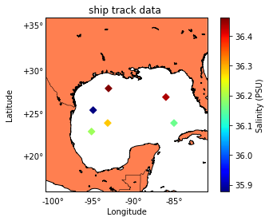

```python
plt.figure()

m=Basemap(projection='mill', llcrnrlon=lon_data.min(), urcrnrlon=lon_data.max(),
          llcrnrlat=lat_data.min(), urcrnrlat=lat_data.max(), resolution='i')

m.drawcoastlines()
#m.drawlsmask(land_color='white',ocean_color='gray',lakes=True)
#m.drawlsmask(ocean_color='gray',lakes=True)
m.drawmapboundary()
m.drawcountries()
m.fillcontinents(color = 'coral')

xx,yy=m(p_lons, p_lats)

#cs = m.pcolormesh(xx, yy, sss_data[0,:,:], cmap='jet')

xs, ys = m(tk_lon, tk_lat)
m.scatter(xs, ys, marker='D', c=list(track_results['mean']), cmap='jet')

m.drawmeridians(np.linspace(-100, -80, num=5, endpoint=True),
                labels = [0,0,0,1],
                linewidth = 0,
                labelstyle ='+/-',
                yoffset = 80000)

m.drawparallels(np.linspace(15, 35, num=5, endpoint=True),
                labels = [1,0,0,0],
                linewidth = 0,
                labelstyle = '+/-',
                xoffset = 20000)

plt.xlabel('Longitude', labelpad = 20)
plt.ylabel('Latitude', labelpad = 40)

cbar = plt.colorbar()
cbar.set_label('Salinity (PSU)')
plt.title("ship track data ")
plt.show()
```